# Week 7 · Class 1

Multivariate Models & Categorical Predictors and Interactions

Sean Westwood

Segment A — Multivariate Models

## In Today’s Class

**Segment A — Multivariate Models**

- Adding multiple predictors to regression
- “Controlling” for confounding variables
- Simpson’s paradox: when aggregation misleads
- Model building strategies
- Understanding R² and model fit

**Segment B — Categorical Predictors and Interactions**

- Including categorical variables in regression models
- Dummy variables and reference categories
- Interaction terms and conditional relationships
- Interpreting models with multiple categorical predictors

## Does Trade Prevent War?

**Observation**: Countries that trade more with each other fight less

**Simple interpretation**: Trade prevents war

**The problem**: This ignores other important factors

- Geographic distance (neighbors trade more AND fight more)
- Economic development (rich countries trade more AND have fewer conflicts)
- Democratic institutions (democracies trade more AND fight less)
- Alliance relationships (allies trade more AND don’t fight each other)

**Simple correlation can be deeply misleading when confounders are present**

## Simpson’s Paradox

A relationship that appears in aggregated data disappears or reverses when we examine subgroups

**The mechanism**:

- A confounder is **unevenly distributed** across groups
- Aggregating hides that imbalance — the confounder’s effect masquerades as the main relationship

**International Relations example**:

- Overall: Larger military spending predicts more international conflicts
- Within regime types: Democracies with high military spending may be more peaceful
- The confounding variable (regime type) creates a misleading overall pattern

**Multivariate analysis helps us see through these misleading patterns**

## All Countries Pooled

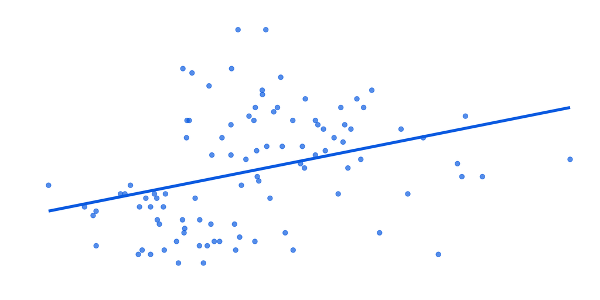

## Now Break It Down by Regime Type

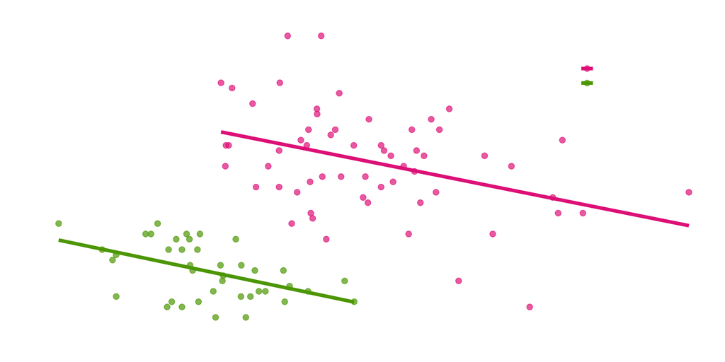

Controlling for Confounders

## What Are Confounders? (Reminder)

**Confounding Variables (Z)**: Variables that affect both X and Y, creating spurious relationships

**Key characteristics:**

- Z causes both the independent variable (X) and dependent variable (Y)
- Z creates a “backdoor path” between X and Y
- Ignoring Z leads to biased estimates of X’s effect on Y
- Z explains away part of the apparent X → Y relationship

## The Logic of Statistical Control

**“Holding constant”** means: compare observations that have the **same value of Z** but **differ in X**, and see how Y changes.

**Example**: Does education predict immigration attitudes, or is partisanship doing the work?

- **Among Democrats only**: Do college-educated Democrats support immigration more than non-college Democrats?
- **Among Republicans only**: Do college-educated Republicans support immigration more than non-college Republicans?

If the education effect is similar **within both groups**, education has a real effect beyond partisanship. Multivariate regression does this comparison across **all values of Z simultaneously**.

## Eight Voters, One Question

Suppose we survey 8 people about immigration support (0–100):

| Person | Education | Party | Immigration Support |
| --- | --- | --- | --- |
| 1 | No College | Dem | 65 |
| 2 | College | Dem | 75 |
| 3 | No College | Dem | 60 |
| 4 | College | Dem | 70 |
| 5 | No College | Rep | 30 |
| 6 | College | Rep | 40 |
| 7 | No College | Rep | 25 |
| 8 | College | Rep | 35 |

## The Education Gap Survives

| Comparison | College Avg | No College Avg | Gap |
| --- | --- | --- | --- |
| **Overall** | 55 | 45 | **10** |
| **Within Democrats** | 72.5 | 62.5 | **10** |
| **Within Republicans** | 37.5 | 27.5 | **10** |

**The gap stays the same within each group** → Education’s effect is real, not driven by party

If party had inflated the gap (e.g., college voters are disproportionately Democrats), the within-group gaps would **shrink**. That’s what “controlling” reveals.

## When the Effect Doesn’t Survive

Now suppose we ask: does **income** predict immigration support?

Notice: most high-income people happen to be Democrats

| Person | Income | Party | Immigration Support |
| --- | --- | --- | --- |
| 1 | High | Dem | 66 |
| 2 | High | Dem | 64 |
| 3 | High | Dem | 68 |
| 4 | High | Rep | 32 |
| 5 | Low | Dem | 64 |
| 6 | Low | Rep | 28 |
| 7 | Low | Rep | 30 |
| 8 | Low | Rep | 32 |

## The Effect Was Spurious

| Comparison | High Income Avg | Low Income Avg | Gap |
| --- | --- | --- | --- |
| **Overall** | 57.5 | 38.5 | **19** |
| **Within Democrats** | 66 | 64 | **2** |
| **Within Republicans** | 32 | 30 | **2** |

**The gap shrinks from 19 to 2 within each group** → Income’s apparent effect was really party doing the work. High-income people just happened to be more Democratic.

**This is what “controlling” does**: it separates the real effect of X from the confounding influence of Z. If the effect **survives**, X matters. If it **shrinks or disappears**, Z was the true driver.

## Why Not Just Subset the Data?

Splitting by Z worked for our example — why not always do that?

**Problem 1**: Z is often **continuous**

If Z is age, you’d need a separate group for every value:

- Age = 31: 4 people
- Age = 32: 3 people
- Age = 33: 2 people
- Age = 34: 0 people…

You can’t compute a reliable average with 2–3 people per group, and some groups are empty.

## Why Not Just Subset? (continued)

**Problem 2**: You usually have **multiple confounders**

Suppose you need to control for party, income, age, AND region:

- Democrat + High Income + Age 35 + Northeast → **1 person**
- Republican + Low Income + Age 42 + South → **0 people**

Each additional confounder **multiplies** the number of groups. With 4 confounders you could need hundreds of groups — most will have too few observations to learn anything.

## So What Does Regression Do Instead?

Regression is like **automatic subsetting** — it compares observations with similar Z values across the entire dataset and estimates a single coefficient for X, all in one equation.

**What regression gives you**:

- Handles continuous and categorical confounders the same way
- Controls for multiple confounders simultaneously
- Uses **all** observations at once (no tiny subgroups)
- Produces a single, clean estimate of X’s effect

## Visualizing Statistical Control

**Without Control**

```
flowchart TD
    Z1[Partisanship] --> X1[College Degree]
    Z1 --> Y1[Support for Immigration]
    X1 -.-> Y1

    style Z1 fill:#e6308a,color:#fff
    style X1 fill:#0073e6,color:#fff
    style Y1 fill:#5ba300,color:#fff
```

**With Control: At Fixed Z Values**

```
flowchart TD
    subgraph z0 ["Partisanship = Democrat"]
        X1[College Degree] --> Y1[Support for Immigration]
    end

    style X1 fill:#0073e6,color:#fff
    style Y1 fill:#5ba300,color:#fff
    style z0 fill:#e6308a,color:#fff
```

```
flowchart TD
    subgraph z1 ["Partisanship = Republican"]
        X2[College Degree] --> Y2[Support for Immigration]
    end

    style X2 fill:#0073e6,color:#fff
    style Y2 fill:#5ba300,color:#fff
    style z1 fill:#e6308a,color:#fff
```

Statistical control compares units with the same Z value, eliminating Z’s confounding effect

## Example 1: Campaign Spending and Vote Share

**Question**: What’s the effect of campaign spending on vote share?

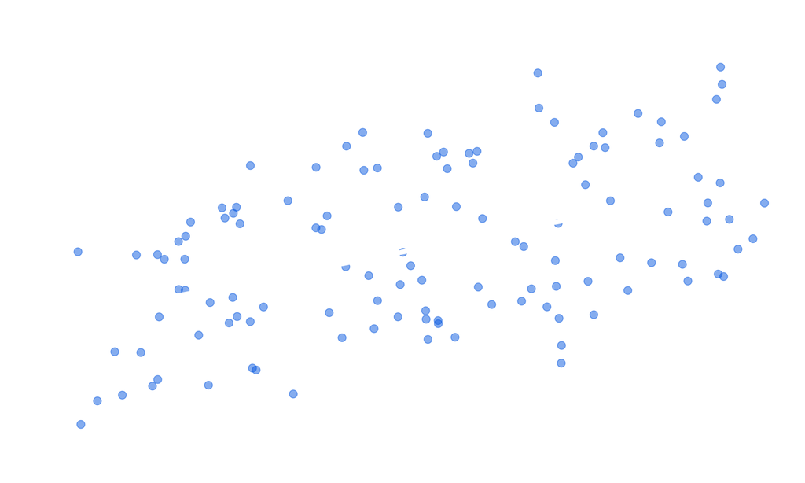

## Campaign Spending and Vote Share

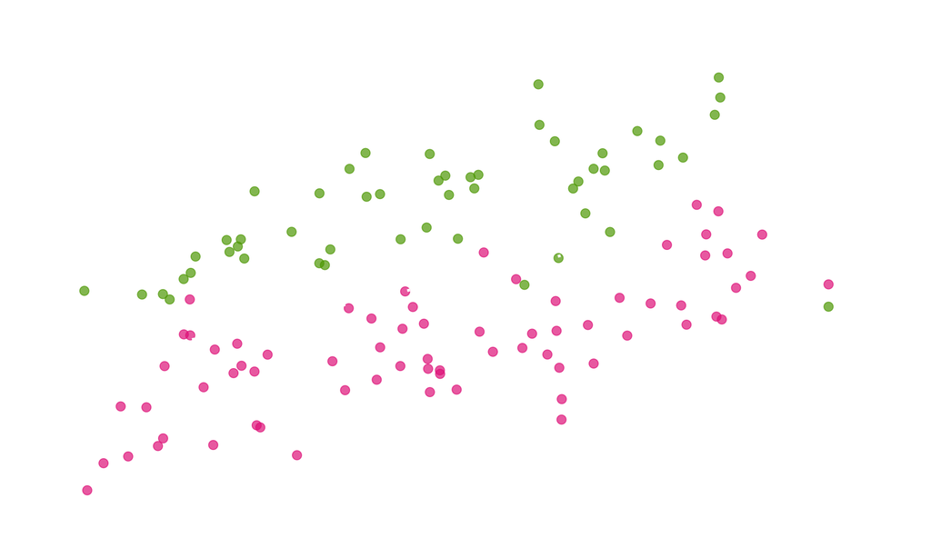

## Campaign Spending and Vote Share

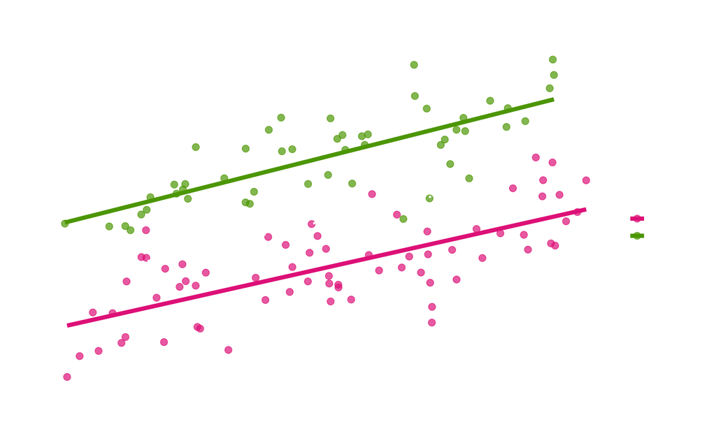

**Intercept shift**:

- The slope barely changes — controlling for incumbency adjusts **baselines**, not the spending effect
- Incumbents just start ~15 points higher

## Example 2: Foreign Aid and Governance

**Question**: Does foreign aid improve governance?

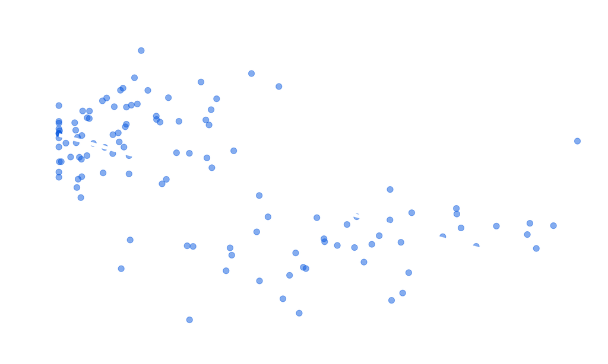

## Foreign Aid and Governance

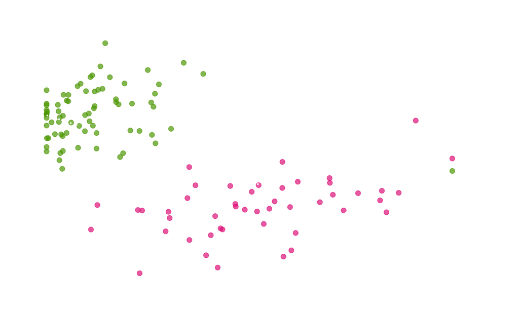

## Foreign Aid and Governance

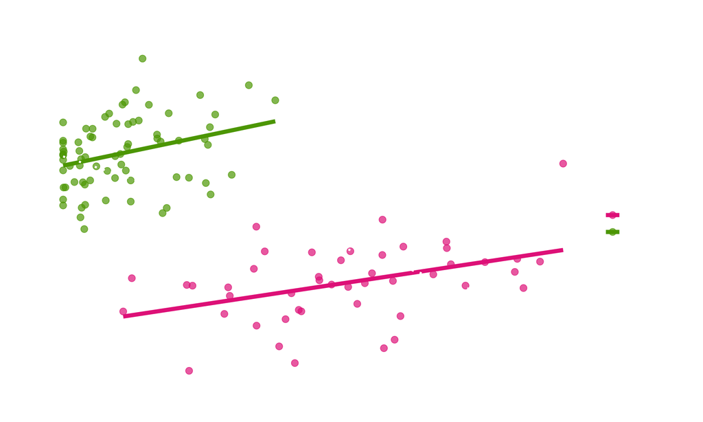

**A full reversal**:

- The overall line slopes **down** (aid looks harmful) — but within each group, aid **helps**
- Conflict history is the confounder: post-conflict countries get more aid *and* have worse governance

## Your First Multivariate Model

**Question**: What’s the effect of age on wages for women?

- **Simple model**: Just age
- **Multivariate model**: Age and having a college degree

```r
# Load motherhood wage data
motherhood_data <- read_csv("../../data/motherhood.csv") %>%
  filter(!is.na(wage), !is.na(age), !is.na(educ)) %>%
  mutate(
    # Create college indicator (1 = college degree, 0 = less than college)
    college_or_more = ifelse(educ == "4.College", 1, 0),
    # Convert wage to thousands for easier interpretation
    wage_thousands = wage / 1000
  ) %>%
  filter(wage > 0, age >= 18, age <= 65)

# Simple model: just age
simple_model <- lm(wage_thousands ~ age, data = motherhood_data)

# Multivariate model: age + education
multi_model <- lm(wage_thousands ~ age + college_or_more, data = motherhood_data)
```

## Comparing Simple vs Multivariate Results

```r
# Compare the models
tidy(simple_model)
```

```
# A tibble: 2 × 5
  term        estimate std.error statistic  p.value
  <chr>          <dbl>     <dbl>     <dbl>    <dbl>
1 (Intercept)  -1.11     0.129       -8.63 6.96e-18
2 age           0.0969   0.00530     18.3  6.95e-74
```

```r
tidy(multi_model)
```

```
# A tibble: 3 × 5
  term            estimate std.error statistic  p.value
  <chr>              <dbl>     <dbl>     <dbl>    <dbl>
1 (Intercept)      -0.769    0.133       -5.79 7.16e- 9
2 age               0.0780   0.00558     14.0  4.68e-44
3 college_or_more   0.590    0.0568      10.4  3.02e-25
```

- The age coefficient **changed** once education entered the model
- The education effect dwarfs it: a college degree ≈ **7.6 years** of age

## Visualizing the Age-Wage Relationship

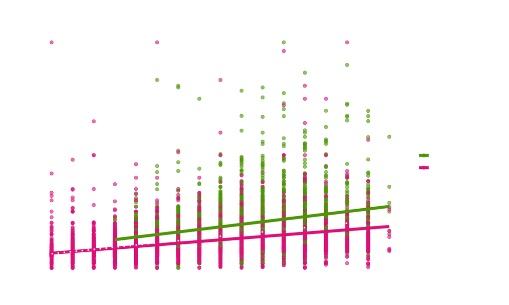

## From One Slope to Two

Returning to the age + college wage model from a few slides back, here’s what the math looks like in general form.

**Simple regression** (one predictor):

$$\hat{Y} = \alpha + \beta X$$

One intercept, one slope → one line through the data

**Multivariate regression** (two predictors):

$$\hat{Y} = \alpha + \beta_1 X_1 + \beta_2 X_2$$

One intercept ($\alpha$), **two slopes** ($\beta_1$, $\beta_2$) → each slope tells you the effect of one variable, holding the other fixed

## Parallel Lines: One Slope, Shifted Intercepts

Our wage model: $\widehat{Wage} = \alpha + \beta_1 \cdot Age + \beta_2 \cdot College$

**For non-college workers** (College = 0):

$$\widehat{Wage} = \alpha + \beta_1 \cdot Age$$

**For college workers** (College = 1):

$$\widehat{Wage} = (\alpha + \beta_2) + \beta_1 \cdot Age$$

Same slope ($\beta_1$), different intercept — college shifts the line up by $\beta_2$

## Assumption: Parallel Slopes

**Multivariate regression without interactions assumes the effect of X on Y is identical across every value of the other predictors.**

In the wage model `lm(wage ~ age + college)`:

- We are assuming **one extra year of age has the same effect on wages** for college graduates and non-college workers.
- Geometrically: the two lines (college vs. non-college) are **parallel** — same slope, different intercepts.

**This is often wrong in real political data.** Examples where slopes likely differ:

- The effect of unemployment on approval may be larger for the **incumbent’s party** than for the opposition
- The effect of campaign spending may be larger for **challengers** than for incumbents
- The effect of age on turnout may be different for **first-time voters** vs. habitual voters

When you suspect different slopes, fit an **interaction model** (`Y ~ X * Z`) — that’s Segment B of today’s class.

## Interpreting Multivariate Coefficients

Each coefficient tells you the effect of that variable **among observations that are identical on all other variables in the model**

**age coefficient**: Among people with the **same education level**, each additional year of age is associated with a $78 increase in wages

**college_or_more coefficient**: Among people who are the **same age**, college graduates earn an additional $590 per week

**Making a prediction**: For a 30-year-old with a college degree:

Predicted wage = -0.77 + 0.08 × 30 + 0.59 × 1 = **$2160** per week

## Computing Predictions with Controls

**The formula**: $\hat{Y} = \alpha + \beta_1 X_1 + \beta_2 X_2 + ...$

Plug in values for **every** variable in the model — both the predictor you care about and the controls.

```r
# Our multivariate model: wage ~ age + college_or_more
tidy(multi_model)
```

```
# A tibble: 3 × 5
  term            estimate std.error statistic  p.value
  <chr>              <dbl>     <dbl>     <dbl>    <dbl>
1 (Intercept)      -0.769    0.133       -5.79 7.16e- 9
2 age               0.0780   0.00558     14.0  4.68e-44
3 college_or_more   0.590    0.0568      10.4  3.02e-25
```

## Prediction Examples: By Hand

$\hat{Y} = \alpha + \beta_1 \cdot Age + \beta_2 \cdot College$

**Person A**: 25, no college

$\hat{Y} = -0.77 + 0.08 \times 25 + 0.59 \times 0$

$= -0.77 + 1.95 + 0$

$= 1.18 \text{ (thousands)}$

Predicted wage: **$1180/week**

**Person B**: 25, college degree

$\hat{Y} = -0.77 + 0.08 \times 25 + 0.59 \times 1$

$= -0.77 + 1.95 + 0.59$

$= 1.77 \text{ (thousands)}$

Predicted wage: **$1771/week**

The difference ($1771 − $1180 = **$590**) is exactly the college coefficient — the predicted effect of college **at the same age**.

Model Building Strategies

## How Many Variables Should You Include?

**The bias-variance tradeoff**:

**Bias**: Systematic error from wrong assumptions (missing important variables)

- Your estimates consistently miss the true effect
- **Example**: Age appears to strongly predict wages, but it’s really education doing the work

**Variance**: Sensitivity to small changes in your data (too many variables)

- Your estimates jump around with different samples
- **Example**: Including 50 variables makes predictions unstable and unreliable

**The Tradeoff**:

- **Too few variables**: High bias (omitted variable bias), low variance
- **Too many variables**: Low bias, high variance (overfitting and multicollinearity)

## Visualizing the Bias-Variance Tradeoff

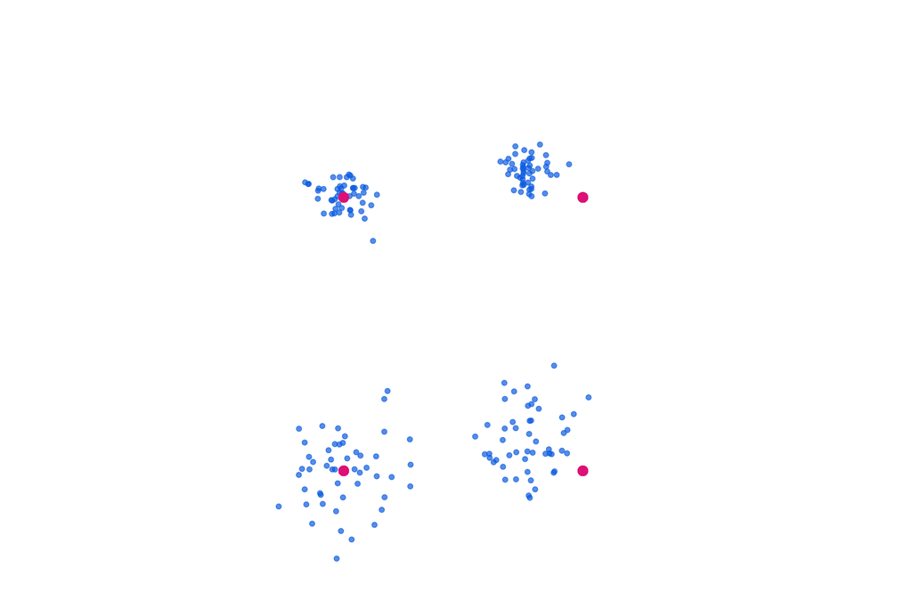

We want models in the top-left quadrant - close to the truth (low bias) and consistent across samples (low variance)

## Choosing Control Variables

**The key question**: Does this variable plausibly affect **both** my main predictor (X) **and** my outcome (Y)?

**Include** a variable as a control if:

- Theory or prior research identifies it as a confounder
- It is a plausible common cause of X and Y (creates a “backdoor path”)
- Leaving it out would bias your estimate of X’s effect

**Don’t include** a variable if:

- It is a **consequence** of X (a mediator) — controlling for it absorbs the very effect you’re trying to measure
- It is unrelated to either X or Y — just adds noise and wastes degrees of freedom
- It is measured **after** the treatment/main predictor (post-treatment bias) — e.g., if education → income → health, controlling for income absorbs part of education’s effect on health

## Exploring Presidential Approval

```r
# Load presidential approval data
approval_data <- read_csv("../../data/presidential_approval.csv") %>%
  mutate(
    year = as.numeric(format(as.Date(date), "%Y")),
    approve = approval_rating
  ) %>%
  filter(!is.na(approve), !is.na(year)) %>%
  mutate(
    post_9_11 = ifelse(year >= 2001, 1, 0),
    post_2008_crisis = ifelse(year >= 2008, 1, 0),
    decades_since_1980 = (year - 1980) / 10
  )

# Look at the data structure
head(approval_data)
```

```
# A tibble: 6 × 7
  date       approval_rating  year approve post_9_11 post_2008_crisis
  <date>               <dbl> <dbl>   <dbl>     <dbl>            <dbl>
1 1980-01-15            58.2  1980    58.2         0                0
2 1980-02-15            55.8  1980    55.8         0                0
3 1980-03-15            39.4  1980    39.4         0                0
4 1980-04-15            40.1  1980    40.1         0                0
5 1980-05-15            43.2  1980    43.2         0                0
6 1980-06-15            31.8  1980    31.8         0                0
# ℹ 1 more variable: decades_since_1980 <dbl>
```

## Building Models Sequentially

```r
tidy(lm(approve ~ decades_since_1980, data = approval_data))
```

```
# A tibble: 2 × 5
  term               estimate std.error statistic   p.value
  <chr>                 <dbl>     <dbl>     <dbl>     <dbl>
1 (Intercept)           57.3      0.921     62.3  8.16e-245
2 decades_since_1980    -3.21     0.369     -8.72 3.76e- 17
```

```r
tidy(lm(approve ~ decades_since_1980 + post_9_11, data = approval_data))
```

```
# A tibble: 3 × 5
  term               estimate std.error statistic   p.value
  <chr>                 <dbl>     <dbl>     <dbl>     <dbl>
1 (Intercept)           56.3      0.995     56.6  1.30e-225
2 decades_since_1980    -1.53     0.732     -2.10 3.64e-  2
3 post_9_11             -4.94     1.86      -2.65 8.22e-  3
```

```r
tidy(lm(approve ~ decades_since_1980 + post_9_11 + post_2008_crisis, data = approval_data))
```

```
# A tibble: 4 × 5
  term               estimate std.error statistic   p.value
  <chr>                 <dbl>     <dbl>     <dbl>     <dbl>
1 (Intercept)           53.6      1.11      48.2  8.63e-195
2 decades_since_1980     1.20     0.895      1.34 1.80e-  1
3 post_9_11             -4.90     1.82      -2.69 7.27e-  3
4 post_2008_crisis      -8.70     1.71      -5.09 5.11e-  7
```

## Watching Coefficients Move

**What to notice**: watch the `decades_since_1980` coefficient as each event indicator enters.

- When a coefficient **moves** after adding a control, the two variables were entangled — the simple trend was partly absorbing those events
- When it **holds steady**, the original estimate was robust to that control

This before/after comparison is the everyday habit of multivariate analysis.

An Example: Afghan Survey Data

## The Afghan Civilian Survey

**The Study**: Survey of Afghan civilians during the war (ISAF/Taliban conflict)

**Research Question**: Which demographic factors predict whether civilians experienced violence by armed groups?

**Key Variables**:

- **Outcome**: `violence` - measure experiences of ISAF violence (yes or no)
- **Predictors**: Age, education years, employment status
- **Context**: Rural Afghan civilians navigating conflict between international forces and Taliban

**Why This Matters**:

- Understanding **civilian experiences** in conflict zones
- Examining how **socioeconomic factors** predict exposure to wartime violence
- Testing whether **age and education effects** change when controlling for employment

## Multiple Predictors of Violence Experiences

```r
# Load and explore Afghan survey data
afghan_data <- read_csv("../../data/afghan.csv") %>%
  filter(!is.na(violent.exp.ISAF), !is.na(age), !is.na(educ.years), !is.na(income)) %>%
  # Create cleaner variable names
  rename(
    violence = violent.exp.ISAF,
    education = educ.years
  )

# Look at the data
head(afghan_data) %>%
  select(age, education, employed, violence)
```

```
# A tibble: 6 × 4
    age education employed violence
  <dbl>     <dbl>    <dbl>    <dbl>
1    26        10        0        0
2    49         3        1        0
3    60         0        1        1
4    34        14        1        0
5    21        12        1        0
6    42         6        1        0
```

## Four Models: Comparing Different Predictors

```r
# Model 1: Just age
model1 <- lm(violence ~ age, data = afghan_data)

# Model 2: Just employed
model2 <- lm(violence ~ employed, data = afghan_data)

# Model 3: Just education
model3 <- lm(violence ~ education, data = afghan_data)

# Model 4: All three predictors
model4 <- lm(violence ~ age + employed + education, data = afghan_data)
```

## Model Comparison Table

Coefficient Estimates: How Effects Change Across Models

| Variable | Age Only | Employed Only | Education Only | Full Model |
| --- | --- | --- | --- | --- |
| (Intercept) | 0.37 | 0.401 | 0.442 | 0.442 |
| Age | 0 | — | — | 0.001 |
| Employed | — | -0.044 | — | -0.035 |
| Education (years) | — | — | -0.016 | -0.016 |
| N | 2584 | 2584 | 2584 | 2584 |

- How do coefficients change when adding other variables?
- Which individual predictor has the largest effect?
- Do the signs and magnitudes make substantive sense?

Understanding Model Fit: $R^2$

## $R^2$ with Multiple Predictors

**Recall from Week 5**: $R^2$ is the share of variance in Y your model explains (0 to 1), and whether a value is “good” depends on context.

**What’s new with multiple predictors**:

**$R^2$ never goes down when you add a variable** — even a useless one

- OLS can set the new coefficient to ~0, so fit can’t get worse
- Random noise usually nudges $R^2$ *up*

**Adjusted $R^2$** charges a small penalty per predictor

- Rises only when a variable explains **more than chance would**
- *Falls* when you add junk → use it to compare models

## $R^2$ for Our Afghan Violence Models

Model Fit: How Much Variation Do We Explain?

| Model | R² | Adjusted R² | % Variance Explained |
| --- | --- | --- | --- |
| Age Only | 0.0000 | -0.0004 | 0% |
| Employed Only | 0.0020 | 0.0016 | 0.2% |
| Education Only | 0.0260 | 0.0257 | 2.6% |
| Full Model | 0.0274 | 0.0263 | 2.7% |

**Questions to Consider**:

- Which single variable is most predictive?
- The full model has the highest $R^2$ — it must, since it contains every predictor. Does its **adjusted** $R^2$ say the extra variables earned their place?
- Are these values “good”? (Context matters — recall Week 5)

## Anscombe’s Quartet: Why $R^2$ Isn’t Everything

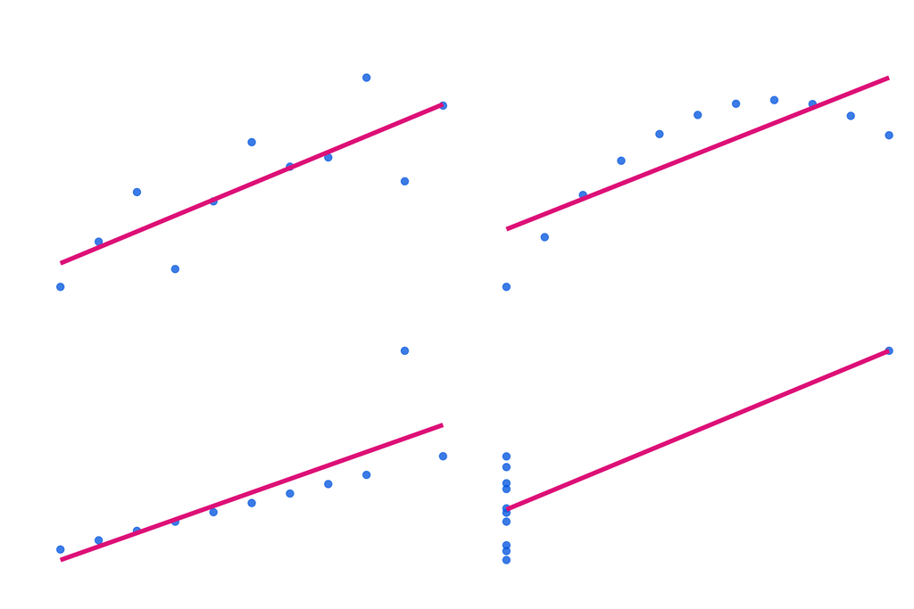

**Lesson**: Always visualize your data! Statistics alone can be misleading.

## The Danger of R² Hunting

**R² Hunting**: Keep adding variables until you get a high R²

**Problem**: This leads to **overfitting**

**What is Overfitting?**

- Model fits your specific dataset very well
- But performs poorly on new data
- Like memorizing answers instead of understanding concepts

**Solution**: Have **principled reasons** for including variables

- Theory suggests they’re important confounders
- Prior research shows they matter
- They’re correlated with both X and Y

**Remember**: A model with R² = 0.3 that makes theoretical sense is better than R² = 0.8 with random variables

Cautions and Practical Guidelines

## What Multivariate Regression Can and Cannot Do

**What it CAN do**:

- Control for **observed** confounders
- Estimate each variable’s partial effect
- Test whether a relationship survives controls

**What it CANNOT do**:

- Control for **unobserved** confounders
- Prove causation
- Fix a poor research design

**Three pitfalls to avoid**:

- **Overfitting**: too many variables relative to sample size — R² climbs, but the model is memorizing noise
- **Multicollinearity**: highly correlated predictors make estimates unstable
- **Post-treatment bias**: controlling for a *consequence* of your main predictor absorbs the very effect you want to measure

**Theory should guide which variables to include, not just statistical fit** — and be honest about what your model can’t rule out.

Segment B — Categorical Predictors and Interactions

## Putting Categories into a Regression

**Problem**: Regression needs numbers, but politics is full of categories

**Examples**:

- Party affiliation (Republican, Democrat, Independent, …)
- Nationality (American, Canadian, British, …)
- Gender (Male, Female, …)
- Education level (High School, College Graduate, …)

**Solution**: Use categorical variables (factors) directly in regression models

## Factors in R

**Factor**: R’s data type for categorical variables

- Stores the category labels (“White”, “Black”, “Hispanic”, “Asian”) plus an internal numeric coding
- In regression, **R automatically expands a factor into 0/1 dummy variables** — one per category, minus a reference (next slide)
- Order matters only for **ordinal** variables, not **nominal** ones:
  - Education is ordinal — “college graduate” *is* more than “high school graduate”
  - Race is nominal — “Asian” is not more than “White”

## How Categorical Variables Become Numbers

We need to be able to represent categorical variables in a model. We will “decompose” the categorical variable into multiple dummy variables.

**The decomposition process**: One categorical variable → Multiple dummy variables

- For example, if we have a variable `race` with four levels: “White”, “Black”, “Hispanic”, “Asian”, we can create three dummy variables: `Black`, `Hispanic`, and `Asian`.
- The reference category is “White”.
- The dummy variables are binary variables that are 1 if the observation is in the level and 0 otherwise.
- For example, if the observation is “Black”, then `Black` is 1 and the other dummy variables are 0.

```
# A tibble: 4 × 5
  respondent_id race     Black Hispanic Asian
          <int> <chr>    <dbl>    <dbl> <dbl>
1             1 White        0        0     0
2             2 Black        1        0     0
3             3 Hispanic     0        1     0
4             4 Asian        0        0     1
```

## Party and Vote Share in R

```r
# Model with party factor - R creates dummy variables automatically
party_model <- lm(vote_share ~ party, data = campaign_data)
tidy(party_model)
```

```
# A tibble: 3 × 5
  term            estimate std.error statistic p.value
  <chr>              <dbl>     <dbl>     <dbl>   <dbl>
1 (Intercept)         13.1      21.4     0.611   0.542
2 partyRepublican     14.9      21.5     0.695   0.487
3 partyDemocrat       12.1      21.5     0.563   0.574
```

**Interpretation**:

- **Intercept**: Average vote share for reference category (Independent)
- **partyRepublican**: How much more Republicans get compared to Independents
- **partyDemocrat**: How much more Democrats get compared to Independents

## The Reference Category

```
flowchart TD
    B["Reference category:<br>INDEPENDENT"]

    B --> D1["Democrat dummy<br>1 if Democrat, else 0"]
    B --> D2["Republican dummy<br>1 if Republican, else 0"]
    B --> D3["Independent<br>no dummy — reference"]

    D1 --> E["Democrat coefficient:<br>gap vs. Independent"]
    D2 --> F["Republican coefficient:<br>gap vs. Independent"]
    D3 --> H["Intercept: average<br>for Independents"]

    classDef reference fill:#5ba300,stroke:#89ce00,stroke-width:2px,color:#fff
    classDef dummy fill:#0073e6,stroke:#4fc3f7,stroke-width:2px,color:#fff
    classDef coeff fill:#b51963,stroke:#e6308a,stroke-width:2px,color:#fff

    class B,D3,H reference
    class D1,E dummy
    class D2,F coeff
```

Every coefficient tells you the difference from the reference group.

## Why Do We Need a Reference?

Suppose we included all k dummies — Democrat, Republican, *and* Independent:

- The three dummies would always sum to 1 for every observation — exactly the same as the model’s intercept
- That’s perfect multicollinearity (the **“dummy variable trap”**): the model can’t tell the intercept apart from the dummies
- R will silently drop one dummy for you if you try

Dropping one category ourselves makes the comparison explicit: each coefficient is the gap from the dropped (reference) category.

## Adding Multiple Categorical Predictors

```r
# Model with party and gender factors
multi_categorical_model <- lm(vote_share ~ party + gender_factor, data = demo_campaign)
tidy(multi_categorical_model)
```

```
# A tibble: 4 × 5
  term                estimate std.error statistic   p.value
  <chr>                  <dbl>     <dbl>     <dbl>     <dbl>
1 (Intercept)           48909.     1896.    25.8   0.0000134
2 partyRepublican       -4030.     2190.    -1.84  0.140
3 partyDemocrat          4697.     2190.     2.14  0.0985
4 gender_factorFemale    -818.     1756.    -0.466 0.665
```

**Interpretation**:

- **partyRepublican**: Republicans vs Others, holding gender constant
- **partyDemocrat**: Democrats vs Others, holding gender constant
- **genderFemale**: Women vs Men, holding party constant

## More Dummy-Variable Examples

Categorical Variable Decomposition Examples

| Variable | All Levels | Reference Level | Dummy Variables Estimated |
| --- | --- | --- | --- |
| Gender | Male, Female | Male | Female |
| Education Level | High School, College, Graduate | High School | College, Graduate |
| Geographic Region | Northeast, South, Midwest, West | Northeast | South, Midwest, West |
| Vote Choice | Democrat, Republican, Independent | Independent | Democrat, Republican |
| Income Level | Low, Middle, High, Very High | Low | Middle, High, Very High |

**Pattern**: For K categories, we estimate K-1 dummy variables. The reference category is excluded to avoid perfect collinearity.

Interaction Terms: When Relationships Depend on Context

## Interactions

**Interaction effect**: How the relationship between X and Y changes depending on a third variable Z

**Political examples**:

- Does education affect voting differently for men vs women?
- Does economic performance matter more for incumbent vs challenger candidates?
- Do campaign ads work differently in competitive vs safe districts?

## Example 1: Education × Gender Interaction

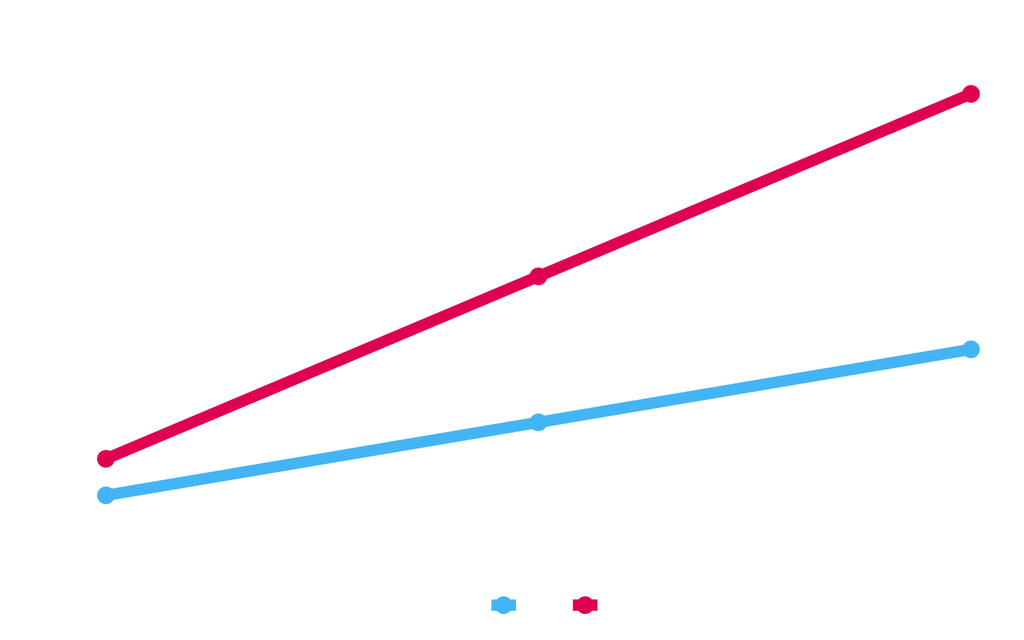

## Example 2: Economy × Incumbent Interaction

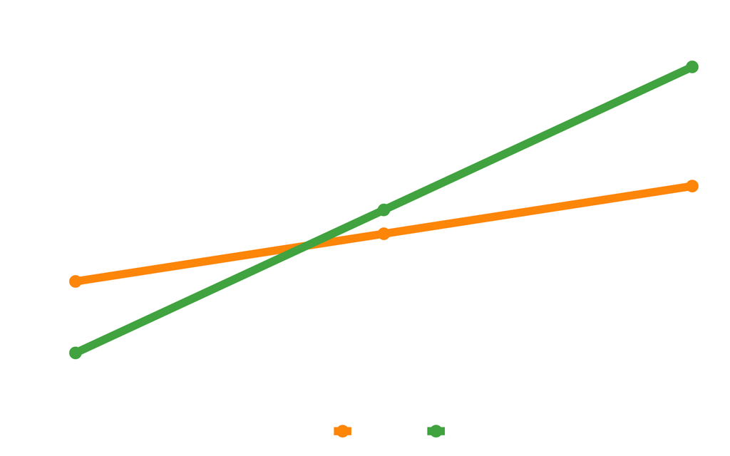

## Example 3: Campaign Ads × District Type Interaction

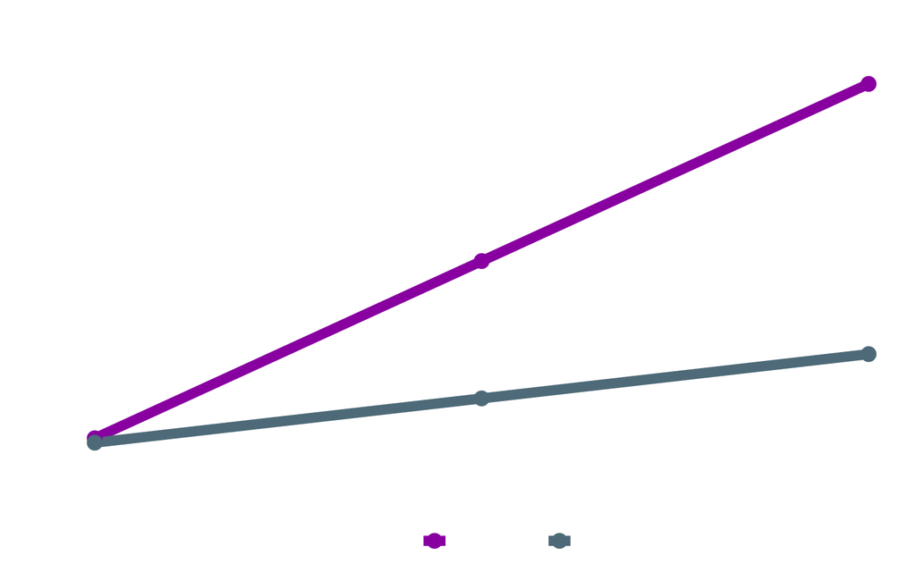

**Notice the** different slopes** for each group! When lines are parallel = no interaction. When slopes differ = interaction present.

## Visualizing Interactions: Parallel vs. Non-Parallel Lines

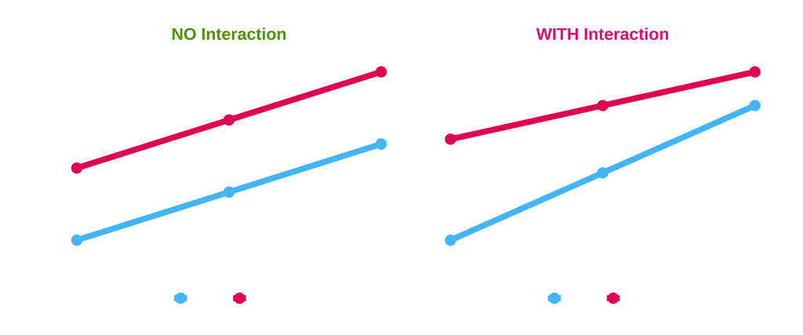

**Key insight**: Look at the slopes! If lines are parallel, there’s no interaction. If lines cross or diverge, there IS an interaction - the effect of X depends on which group you’re in.

## What Is an Interaction Term?

**Interaction Term**: An interaction term is the product `X * Z`. Its coefficient says **how much X’s slope changes as Z changes** — i.e., the effect of one variable **depends on** the level of another.

**Think of it this way**:

- **Main effect**: “Does X affect Y?”
- **Interaction effect**: “Does X affect Y **differently** for different groups?”

**Example**: Do Republicans and Democrats justify political violence differently based on shooter’s party?

- Main effect: Party ID → Violence justification
- Interaction: Party ID × Shooter alignment → Justification varies by alignment

**Mathematical representation**:
$$Y = \beta_0 + \beta_1X + \beta_2Z + \beta_3(X \times Z) + \epsilon$$

Where $\beta_3$ captures how the effect of X on Y changes as Z changes.

## Creating Interaction Terms

To create an interaction term, you can use the `*` operator in the formula.

```r
# Model with interaction between party ID and shooter alignment
interaction_model <- lm(violence_justified ~ party_id*shooter_alignment,
                       data = violence_data)

tidy(interaction_model)
```

```
# A tibble: 4 × 5
  term                                     estimate std.error statistic  p.value
  <chr>                                       <dbl>     <dbl>     <dbl>    <dbl>
1 (Intercept)                               0.0979     0.0131     7.45  1.42e-13
2 party_idRepublican                       -0.00883    0.0189    -0.467 6.41e- 1
3 shooter_alignmentIn-Party Shooter         0.00886    0.0185     0.478 6.32e- 1
4 party_idRepublican:shooter_alignmentIn-… -0.0286     0.0267    -1.07  2.84e- 1
```

- **party_idRepublican** ($\beta_1$): the Republican–Democrat difference **when the shooter is out-party** (the reference condition)
- **shooter_alignmentIn-Party Shooter** ($\beta_2$): the in-party vs. out-party difference **among Democrats** (the reference party)
- **party_idRepublican:shooter_alignmentIn-Party Shooter** ($\beta_3$): how much the in-party/out-party difference **changes** for Republicans compared to Democrats

**“Main effects” here are conditional** — each is the effect when the other variable is at its reference (0) level, not an overall average.

## The Four Predicted Values

With two binary variables, the model defines **four predicted values**. Build each one from the coefficients:

Predicted Justification of Violence by Group

| Group | Built From | Predicted |
| --- | --- | --- |
| Democrat, Out-Party Shooter | Intercept | 0.098 |
| Republican, Out-Party Shooter | Intercept + β1 | 0.089 |
| Democrat, In-Party Shooter | Intercept + β2 | 0.107 |
| Republican, In-Party Shooter | Intercept + β1 + β2 + β3 | 0.069 |

**$\beta_3$ is the “difference in differences”** — how much the in-party/out-party gap differs between the two parties. If $\beta_3 = 0$, both parties react identically.

## Interaction with Continuous Variables

```r
# Model with interaction between two continuous variables
continuous_interaction <- lm(violence_justified ~ age * political_engagement, data = continuous_data)

tidy(continuous_interaction)
```

```
# A tibble: 4 × 5
  term                        estimate std.error statistic p.value
  <chr>                          <dbl>     <dbl>     <dbl>   <dbl>
1 (Intercept)               0.0872     0.0698       1.25     0.212
2 age                       0.0000790  0.00145      0.0544   0.957
3 political_engagement     -0.000104   0.00130     -0.0799   0.936
4 age:political_engagement  0.00000209 0.0000271    0.0773   0.938
```

**Interpreting the interaction coefficient** (here 0):

- It is how much the **age slope changes** per one-point increase in engagement (symmetric: also the reverse)
- Here it’s essentially **zero** — the age slope is the same at every engagement level
- **A null interaction is a real finding**: the simpler additive model was adequate

Unlike categorical interactions where we compare groups, continuous interactions tell us how **slopes change** as one variable increases.

When to Use Interactions

## Good and Bad Reasons for an Interaction

**Good reasons for interactions**:

- Theory predicts conditional relationships
- Different groups should respond differently
- Previous research suggests moderation effects
- Substantively important to test

**Poor reasons for interactions**:

- Fishing for significance
- Adding complexity without theory

## Example 1: Regime Type × Economic System (Factor × Factor)

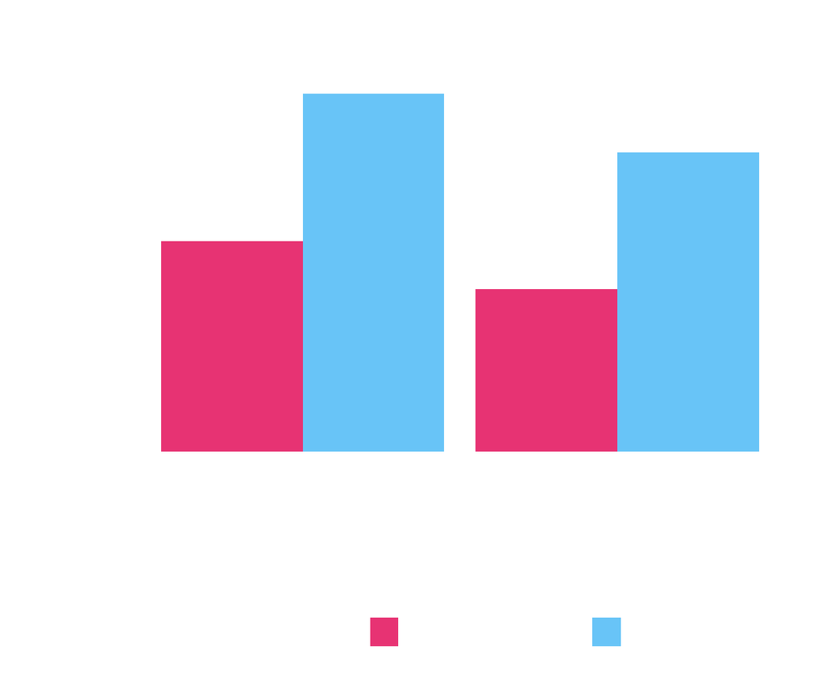

```r
# Regression model
regime_model <- lm(human_rights ~ regime_type * economic_system,
                   data = regime_data)

tidy(regime_model)
```

```
# A tibble: 4 × 5
  term                                     estimate std.error statistic  p.value
  <chr>                                       <dbl>     <dbl>     <dbl>    <dbl>
1 (Intercept)                                 44.0       1.97    22.4   6.52e-40
2 regime_typeDemocratic                       30.8       2.78    11.1   6.72e-19
3 economic_systemPlanned                     -10.1       2.84    -3.55  6.05e- 4
4 regime_typeDemocratic:economic_systemPl…    -2.25      3.94    -0.571 5.69e- 1
```

```r
# Extract coefficients for inline use
regime_coefs <- coef(regime_model)
regime_dem <- round(regime_coefs["regime_typeDemocratic"], 1)
regime_planned <- round(regime_coefs["economic_systemPlanned"], 1)
regime_interact <- round(regime_coefs["regime_typeDemocratic:economic_systemPlanned"], 2)
regime_dem_planned_effect <- round(abs(regime_planned) + abs(regime_interact), 1)
```

- Democracies have 30.8 points higher human rights scores than autocracies (with market economies)
- Planned economies reduce human rights by 10.1 points in autocracies
- The interaction (-2.25) shows planned economies reduce human rights slightly more in democracies, but this effect is not statistically significant
- Overall: Market economies boost human rights by 10.1 points in autocracies vs 12.3 points in democracies

## Example 2: GDP per Capita × Regime Type (Continuous × Factor)

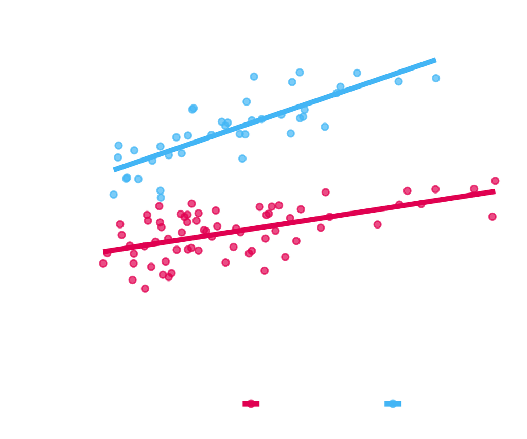

```r
# Regression model
gdp_model <- lm(press_freedom ~ gdp_per_capita * regime_type,
                data = gdp_data)

tidy(gdp_model)
```

```
# A tibble: 4 × 5
  term                                  estimate std.error statistic  p.value
  <chr>                                    <dbl>     <dbl>     <dbl>    <dbl>
1 (Intercept)                          24.0      1.66          14.5  9.59e-27
2 gdp_per_capita                        0.000309 0.0000521      5.93 3.90e- 8
3 regime_typeDemocratic                28.6      2.92           9.80 1.73e-16
4 gdp_per_capita:regime_typeDemocratic  0.000378 0.0000945      4.00 1.18e- 4
```

```r
# Extract coefficients for inline use (multiply by 1000 for per-$1000 interpretation)
gdp_coefs <- coef(gdp_model)
gdp_autocracy <- round(gdp_coefs["gdp_per_capita"] * 1000, 3)
gdp_dem_base <- round(gdp_coefs["regime_typeDemocratic"], 1)
gdp_interact <- round(gdp_coefs["gdp_per_capita:regime_typeDemocratic"] * 1000, 3)
gdp_democracy <- round(gdp_autocracy + gdp_interact, 3)
```

- In autocracies: Each $1,000 increase in GDP per capita increases press freedom by 0.309 points
- In democracies: Each $1,000 increase in GDP per capita increases press freedom by 0.687 points (0.309 + 0.378)
- The interaction shows that GDP has more than twice the effect on press freedom in democracies compared to autocracies
- Democracies start with 28.6 points higher press freedom than autocracies at the same GDP level

## Example 3: Military Spending × Trade Openness (Continuous × Continuous)

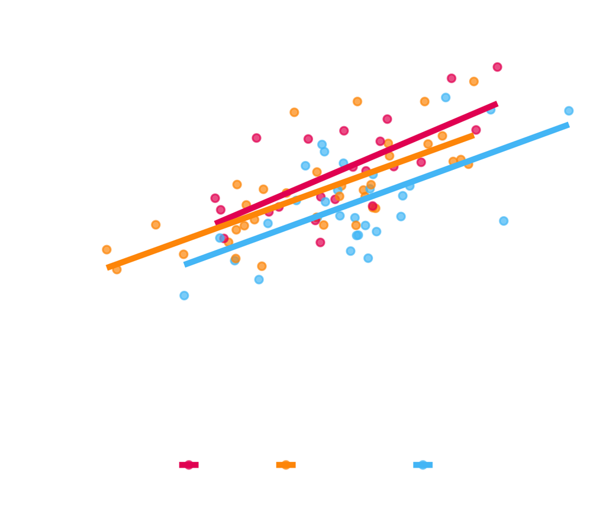

```r
# Regression model
conflict_model <- lm(conflict_risk ~ military_spending * trade_openness,
                     data = conflict_data)

tidy(conflict_model)
```

```
# A tibble: 4 × 5
  term                             estimate std.error statistic  p.value
  <chr>                               <dbl>     <dbl>     <dbl>    <dbl>
1 (Intercept)                       19.4      11.6        1.67  0.0981
2 military_spending                 10.1       2.93       3.43  0.000935
3 trade_openness                    -0.210     0.184     -1.14  0.257
4 military_spending:trade_openness  -0.0384    0.0459    -0.836 0.405
```

Making Predictions from Interaction Models

## Example 1: Education Policy - Class Size × Teacher Experience

```r
edu_model <- lm(test_scores ~ class_size * teacher_experience + school_funding, data = education_data)
tidy(edu_model)
```

```
# A tibble: 5 × 5
  term                           estimate std.error statistic  p.value
  <chr>                             <dbl>     <dbl>     <dbl>    <dbl>
1 (Intercept)                   75.4      4.43          17.0  3.06e-39
2 class_size                    -1.07     0.164         -6.48 8.53e-10
3 teacher_experience             0.416    0.389          1.07 2.87e- 1
4 school_funding                 0.000133 0.0000222      6.02 9.91e- 9
5 class_size:teacher_experience  0.0304   0.0152         2.00 4.67e- 2
```

**Prediction Question**: What are the expected test scores for a class of 20 students with a teacher who has 5 years of experience, in a school with $45,000 funding?

**Manual Calculation**:

$$\hat{Y} = 75.4 + (-1.07 \times 20) + (0.42 \times 5) + (0.00013 \times 45000) + (0.03 \times 20 \times 5)$$

$$= 75.4 + -21.3 + 2.1 + 6 + 3.04 = 65.2$$

## Example 2: Political Behavior - Campaign Spending × Incumbent Status

```r
campaign_model <- lm(vote_share ~ spending_thousands * incumbent + district_competitiveness, data = campaign_data)
tidy(campaign_model)
```

```
# A tibble: 5 × 5
  term                         estimate std.error statistic  p.value
  <chr>                           <dbl>     <dbl>     <dbl>    <dbl>
1 (Intercept)                   49.7      1.30        38.2  2.80e-55
2 spending_thousands             0.0614   0.00576     10.7  2.46e-17
3 incumbent                      4.07     1.97         2.07 4.16e- 2
4 district_competitiveness       0.158    0.0180       8.74 1.77e-13
5 spending_thousands:incumbent  -0.0140   0.00987     -1.42 1.59e- 1
```

**Prediction Question**: What is the expected vote share for a challenger who spends $300,000 in a district with competitiveness score of 55?

$$\hat{Y} = 49.7 + (0.061 \times 300) + (4.07 \times 0) + (0.158 \times 55) + (-0.014 \times 300 \times 0)$$

$$= 49.7 + 18.4 + 0 + 8.7 + 0 = 76.8$$

## Example 3: International Relations - Trade × Regime Type

```r
ir_model <- lm(diplomatic_score ~ trade_volume * democracy_score + gdp_per_capita, data = ir_data)
tidy(ir_model)
```

```
# A tibble: 5 × 5
  term                          estimate std.error statistic  p.value
  <chr>                            <dbl>     <dbl>     <dbl>    <dbl>
1 (Intercept)                  34.0      5.09           6.67 3.45e- 9
2 trade_volume                  0.999    0.155          6.43 9.77e- 9
3 democracy_score               0.401    0.0960         4.17 7.86e- 5
4 gdp_per_capita                0.000359 0.0000490      7.31 2.10e-10
5 trade_volume:democracy_score  0.0161   0.00301        5.35 8.63e- 7
```

**Prediction Question**: What are expected diplomatic relations between countries with $40 billion trade, democracy score of 70, and GDP per capita of $30,000?

$$\hat{Y} = 34 + (1 \times 40) + (0.401 \times 70) + (0.000359 \times 30000) + (0.0161 \times 40 \times 70)$$

$$= 34 + 39.9 + 28 + 10.8 + 45.1 = 157.8$$

## Example 4: Economics - Minimum Wage × Local Unemployment

```r
econ_model <- lm(employment_change ~ min_wage * unemployment_rate + cost_of_living, data = econ_data)
tidy(econ_model)
```

```
# A tibble: 5 × 5
  term                       estimate std.error statistic p.value
  <chr>                         <dbl>     <dbl>     <dbl>   <dbl>
1 (Intercept)                 -3.83      6.49      -0.590  0.557
2 min_wage                    -0.676     0.545     -1.24   0.219
3 unemployment_rate           -1.17      0.941     -1.25   0.217
4 cost_of_living               0.0218    0.0123     1.77   0.0816
5 min_wage:unemployment_rate   0.143     0.0785     1.82   0.0725
```

**Prediction Question**: What is the expected employment change for a minimum wage of $15 in an area with 8% unemployment and cost of living index of 110?

$$\hat{Y} = -3.83 + (-0.676 \times 15) + (-1.17 \times 8) + (0.022 \times 110) + (0.143 \times 15 \times 8)$$

$$= -3.83 + -10.14 + -9.38 + 2.39 + 17.19 = -3.76$$

Limitations and Cautions

## The Costs of Extra Interactions

**Too many interactions**:

- Models become difficult to interpret
- Overfitting risks increase
- Theoretical justification becomes weak

**Small sample sizes within groups**:

- Interactions require sufficient data in each combination
- Consider collapsing categories if groups are too small

**Interpretation complexity**:

- Main effects change meaning in presence of interactions
- Conditional effects must be calculated carefully

Controls vs. Interactions: What’s the Difference?

## Same Ingredients, Different Questions

Both controls and interactions involve adding a third variable Z to a model with X and Y:

- Both involve adding Z alongside X in a regression
- Both require you to think about **why Z matters**
- Both produce models with multiple coefficients

But they answer **fundamentally different questions**:

**Control**: “Does X affect Y, **accounting for** Z?” — Z shifts the baseline, but X’s effect is the **same for everyone**

**Interaction**: “Does X affect Y **differently depending on** Z?” — X’s effect **changes** based on Z

## The Equations Side by Side

**Control (Additive) Model**

$$Y = \beta_0 + \beta_1 X + \beta_2 Z + \epsilon$$

- $\beta_1$ = effect of X on Y (**same** for all values of Z)
- $\beta_2$ = how much Z shifts the baseline
- **One slope for X, shifted intercepts**
- R syntax: `Y ~ X + Z`

**Interaction Model**

$$Y = \beta_0 + \beta_1 X + \beta_2 Z + \beta_3(X \times Z) + \epsilon$$

- $\beta_1$ = effect of X on Y **when Z = 0**
- $\beta_3$ = how much X’s effect **changes** as Z changes
- **Different slopes for X across values of Z**
- R syntax: `Y ~ X * Z`

The only difference is one term: $\beta_3(X \times Z)$. But that one term changes the entire meaning of the model.

## Starting Lines vs. Terrain

**Control** = Runners on different starting lines

- Everyone runs at the **same speed** (same slope)
- But some start further ahead (different intercepts)
- The race track is **the same** for everyone

**Interaction** = Runners on different terrains

- Some run on pavement, others on sand
- The terrain **changes how fast** they can run (different slopes)
- The course itself **differs** by group

**Controls** adjust for **where groups start**. **Interactions** allow for **how groups respond**.

## When Should You Use a Control vs. an Interaction?

```
flowchart LR
    A["Variables:<br>X, Y, Z"] --> B{"Research<br>question?"}

    B -->|"net of Z"| C["Z is a<br>CONFOUNDER"]
    B -->|"varies with Z"| D["Z is a<br>MODERATOR"]

    C --> E["CONTROL<br>Y ~ X + Z"]
    D --> F["INTERACTION<br>Y ~ X * Z"]

    E --> G["One slope<br>parallel lines"]
    F --> H["Different slopes<br>non-parallel lines"]

    classDef question fill:#5ba300,stroke:#89ce00,stroke-width:2px,color:#fff
    classDef confounder fill:#0073e6,stroke:#4fc3f7,stroke-width:2px,color:#fff
    classDef moderator fill:#b51963,stroke:#e6308a,stroke-width:2px,color:#fff
    classDef result fill:#8a5a00,stroke:#ff9800,stroke-width:2px,color:#fff

    class A,B question
    class C,E confounder
    class D,F moderator
    class G,H result
```

**The key question**: Does Z just **shift the baseline** (confounder → control), or does Z **change the relationship** (moderator → interaction)?

## Practice: Control or Interaction?

| Research Question | Z Variable | Answer | Why? |
| --- | --- | --- | --- |
| Does voter turnout affect policy outcomes, **accounting for** district wealth? | District wealth | **Control** | Wealth is a confounder — wealthy districts have both higher turnout and different policies |
| Do sanctions reduce aggression **differently for** democracies vs. autocracies? | Regime type | **Interaction** | Asking whether the effect of sanctions depends on regime type |
| Does social media use predict polarization, **controlling for** age? | Age | **Control** | Age affects both social media use and polarization |
| Does economic anxiety increase populism support **more in** high-inequality countries? | Inequality | **Interaction** | Asking whether inequality amplifies the anxiety-populism link |

**Look for the keywords**: “accounting for,” “controlling for,” “holding constant” → **Control**. “Differently for,” “depends on,” “more in,” “moderated by” → **Interaction**.

## Common Mistakes with Controls and Interactions

**1. Using a control when you need an interaction**

- `Y ~ X + Z` reports one “average” slope (say, 3.5) even if the real effect is **6 for one group and 1 for the other**
- **Detect it**: refit with `Y ~ X * Z` and check the interaction term, or plot Y vs. X separately by Z and compare slopes

**2. Using an interaction when you just need a control**

- If Z is a confounder (not a moderator), the interaction adds complexity for nothing — keep it simple when theory doesn’t predict conditional effects

**3. Forgetting that interactions include controls**

- In R, `Y ~ X * Z` automatically expands to `Y ~ X + Z + X:Z` — the interaction model **nests** the control model, so you get the level shift too

## Controls vs. Interactions: Summary

|  | **Control** | **Interaction** |
| --- | --- | --- |
| **Question** | Does X affect Y, accounting for Z? | Does X affect Y differently by Z? |
| **Z’s role** | Confounder (nuisance) | Moderator (substantive) |
| **Equation** | $Y = \beta_0 + \beta_1 X + \beta_2 Z$ | $Y = \beta_0 + \beta_1 X + \beta_2 Z + \beta_3 XZ$ |
| **Lines** | Parallel (same slope) | Non-parallel (different slopes) |
| **Coefficients** | $\beta_1$ = effect of X (for all Z) | $\beta_1$ = effect when Z=0; $\beta_3$ = change per unit Z |
| **Visual** | Lines shift up/down | Lines fan out or cross |
| **R syntax** | `Y ~ X + Z` | `Y ~ X * Z` |

**One-line rule**: Controls ask “what is X’s effect?” Interactions ask “does X’s effect *vary* with Z?” Both are valid — the choice depends on your research question and theory.

Looking Ahead

## In Our Next Class

**Sampling and Statistical Significance**

- Populations vs. samples, and why sampling creates uncertainty
- Randomization revisited: how chance builds balanced groups
- Margin of error and a first look at the t-distribution
- Hypothesis testing and p-values